# HW3_Jinying (Jinny)_Zhong

2023-01-23

```r
data <- read.csv("/Users/zhongjinying/Desktop/heart.csv")
head(data)
```

```
##   past_pain density age weight height fat_free_wt family_record neck_dim
## 1      12.6  1.0708  23 154.25  67.75       134.9            NA     36.2
## 2       6.9  1.0853  22 173.25  72.25       161.3            NA     38.5
## 3      24.6  1.0414  22 154.00  66.25       116.0            NA     34.0
## 4      10.9  1.0751  26 184.75  72.25       164.7            NA     37.4
## 5      27.8  1.0340  24 184.25  71.25       133.1            NA     34.4
## 6      20.6  1.0502  24 210.25  74.75       167.0            NA     39.0
##   chest_dim abdom_dim past_record hip_dim thigh_dim knee_dim wrist_dim
## 1      93.1      85.2          NA    94.5      59.0     37.3        NA
## 2      93.6      83.0          NA    98.7      58.7     37.3        NA
## 3      95.8      87.9          NA    99.2      59.6     38.9        NA
## 4     101.8      86.4          NA   101.2      60.1     37.3        NA
## 5      97.3     100.0          NA   101.9      63.2     42.2        NA
## 6     104.5      94.4          NA   107.8      66.0     42.0        NA
##   ankle_dim biceps_dim forearm_dim wrist_dim.1 heart_attack
## 1      21.9       32.0        27.4        17.1         23.7
## 2      23.4       30.5        28.9        18.2         23.4
## 3      24.0       28.8        25.2        16.6         24.7
## 4      22.8       32.4        29.4        18.2         24.9
## 5      24.0       32.2        27.7        17.7         25.6
## 6      25.6       35.7        30.6        18.8         26.5
```

# Question 1 (20 pts):

## 1. How would you choose a sample subset (such as missing value, nulls, empty columns) of this dataset? What criteria would you consider when selecting a training subset from the above dataset (such as balanced distribution between training and test for the treated observations) ?

1. Choose a sample subset: I’d exclude all columns with many NAs like ‘family_record’, ‘past_record’ and ‘wrist_dim’. Also, rows with missing values will also be dropped in the sample subset selection. (2) Criteria when select a training subset: similar distribution of key significant variables between training and test subsets. For example, based on the common sense, probability of heart attach positively relates with Age. The elderly are more likely to suffer from heart attack. Thus, in the subset selection, we should try have similar distribution pattern in training and testing sets. We could not train the model mainly based on the elder people but do the testing on over 80 age group.

## 2. Randomly split the dataset into test and training sets using 80% observations as training set. Fit a simple linear regression model (full model) to predict the heart attack probability and test your model against the test set. Explain your model and obtain the R^2 for the predictions of the test data set (i.e., a true OOS R^2).

```r
library(dplyr)
# exclude NA or empty values
deletecol <- c("family_record","past_record","wrist_dim")
data2 <- na.omit(select(data, -deletecol))
# train-test split and develop model
set.seed(888)
test <- sample(1:nrow(data2),nrow(data2)*0.2)
full <- glm(heart_attack~., data=data2[-test,])
summary(full)
```

```
##
## Call:
## glm(formula = heart_attack ~ ., data = data2[-test, ])
##
## Deviance Residuals:
##     Min       1Q   Median       3Q      Max
## -4.9272  -0.4815   0.0568   0.5395   2.5630
##
## Coefficients:
##               Estimate Std. Error t value Pr(>|t|)
## (Intercept)  16.178739  26.818626   0.603 0.547151
## past_pain    -0.269951   0.077533  -3.482 0.000636 ***
## density     -20.948513  24.003969  -0.873 0.384074
## age          -0.006338   0.008474  -0.748 0.455563
## weight        0.089833   0.022101   4.065 7.39e-05 ***
## height       -0.137895   0.022858  -6.033 1.01e-08 ***
## fat_free_wt  -0.129133   0.027772  -4.650 6.72e-06 ***
## neck_dim      0.190100   0.060235   3.156 0.001898 **
## chest_dim     0.125002   0.024561   5.089 9.59e-07 ***
## abdom_dim     0.118288   0.027405   4.316 2.71e-05 ***
## hip_dim       0.073574   0.036572   2.012 0.045854 *
## thigh_dim     0.132341   0.040430   3.273 0.001292 **
## knee_dim     -0.166587   0.066818  -2.493 0.013636 *
## ankle_dim     0.120746   0.051707   2.335 0.020722 *
## biceps_dim    0.045052   0.045052   1.000 0.318765
## forearm_dim   0.064435   0.053545   1.203 0.230529
## wrist_dim.1   0.182155   0.144772   1.258 0.210069
## ---
## Signif. codes:  0 '***' 0.001 '**' 0.01 '*' 0.05 '.' 0.1 ' ' 1
##
## (Dispersion parameter for gaussian family taken to be 0.8945556)
##
##     Null deviance: 2588.70  on 183  degrees of freedom
## Residual deviance:  149.39  on 167  degrees of freedom
## AIC: 519.83
##
## Number of Fisher Scoring iterations: 2
```

```r
# in-sample R^2: 1-(149.39/2588.70)=0.9422915
# predict and test model
full_predict <- predict(full,newdata=data2[test,])
y_bar <- mean(data2[-test,]$heart_attack) #mean of training set
d <- sum((data2[test,]$heart_attack - full_predict)^2) # (yi-y_hat)^2
d0 <- sum((data2[test,]$heart_attack - y_bar)^2) # (test$y - mean(training$y))
(R2 <- 1 - (d/d0))
```

```
## [1] 0.9043618
```

```r
print("The OOS R^2 is 0.9043618, which is lower than the in-sample R^2, 0.9422.")
```

```
## [1] "The OOS R^2 is 0.9043618, which is lower than the in-sample R^2, 0.9422."
```

```r
# explain your model
print("Based on the results, there are 16 variables in the model and 11 of them are statistically significant. It shows that past_pain, height, fat_free_wt, knee_dim are negatively related to the probability of heartattack. Based on the OOS R^2, the model explains 90.43% of the varaition in heart probability taking all these variables.")
```

```
## [1] "Based on the results, there are 16 variables in the model and 11 of them are statistically significant. It shows that past_pain, height, fat_free_wt, knee_dim are negatively related to the probability of heartattack. Based on the OOS R^2, the model explains 90.43% of the varaition in heart p…
```

# Question 2 (10 pts): Explain cross-validation and highlight the problems that may be associated with a cross-validation approach.

1. Cross-validation is a re-sampling method that divides the data into segments, and do model training and testing on different segments on different iterations. The purpose of this train-test separation is to attain a more accurate estimate of the model’s prediction performance by validating the model on data that are not used in development. In k-fold cross-validation, the data would be split into k folds, cycle through K cross validation iterations with a single fold left-out, record and measure the performance.
2. Problems: Cross-validation could be costly as the algorithm need to rerun k times. This is more troublesome and take longer time when k is set to a larger number. Besides, it can be unstable as it trains based on various samples especially when the samples are not representative enough.

# Question 3 (25 pts): Use cross-validation to train (on 7/8 of the training set) and evaluate (on 1/8 of the training set). Calculate the mean R^2 from the 8-fold cross-validation and compare it with the R^2 from question 1. Please explain your observation.

```r
library(caret)
data3 <- data2[-test,]
train_control <- trainControl(method = "cv", number = 8)
model <- train(heart_attack ~., data = data3, method = "lm", trControl = train_control)
print(model)
```

```
## Linear Regression
##
## 184 samples
##  16 predictor
##
## No pre-processing
## Resampling: Cross-Validated (8 fold)
## Summary of sample sizes: 160, 161, 161, 161, 160, 161, ...
## Resampling results:
##
##   RMSE      Rsquared   MAE
##   1.535314  0.8827256  0.8211367
##
## Tuning parameter 'intercept' was held constant at a value of TRUE
```

```r
#summary(model)
print("The Rsquared using cross-validation is 0.8827256, which is lower than that in question 1. One potential reason might be -- the full model we trained previously includes overfitting problems as we include all the variables; however, with cross validation, the variables are chosen in a more conservative way.")
```

```
## [1] "The Rsquared using cross-validation is 0.8827256, which is lower than that in question 1. One potential reason might be -- the full model we trained previously includes overfitting problems as we include all the variables; however, with cross validation, the variables are chosen in a more co…
```

# Question 4 (10 pts): Explain Lasso regression and how does it work. List the pros and cons associated with using it.

1. Explain: Lasso regression performs both the variable selection and regularization in the regression analysis. Instead of purely minimizing deviance, Lasso includes ‘penalty’ term (i.e., considering the costs of including variables into model) in its objective function. That is, the cost function for Lasso regression is similar to that of ordinary least squares (OLS) linear regression, but with the addition of a regularization term. When lambda in the ‘penalty’ term is so large, the value of coefficients are more likely to be set to zero. With the decreasing of lambda value, the model starts to include more variables.
2. Pros: It is helpful in avoiding over fitting problem as it tends to give sparse solutions and set some of the variables to zero and do the model selection automatically. Besides, when there are large amount of feature candidates, Lasso regression could help u to select a subset of them with priority into the model.
3. Cons: Lasso can be sensitive to the scale (or size) of the variables, so we need to do standardization step before using Lasso. Besides, it might generate biased coefficients and can be unstable.

# Question 5

## 1. Fit a Lasso regression to predict the heart attack probability. Use cross-validation to obtain lambda_min as well as lambda_1se. Explain the two resulting models. Which one would you choose?

```r
library(glmnet)
```

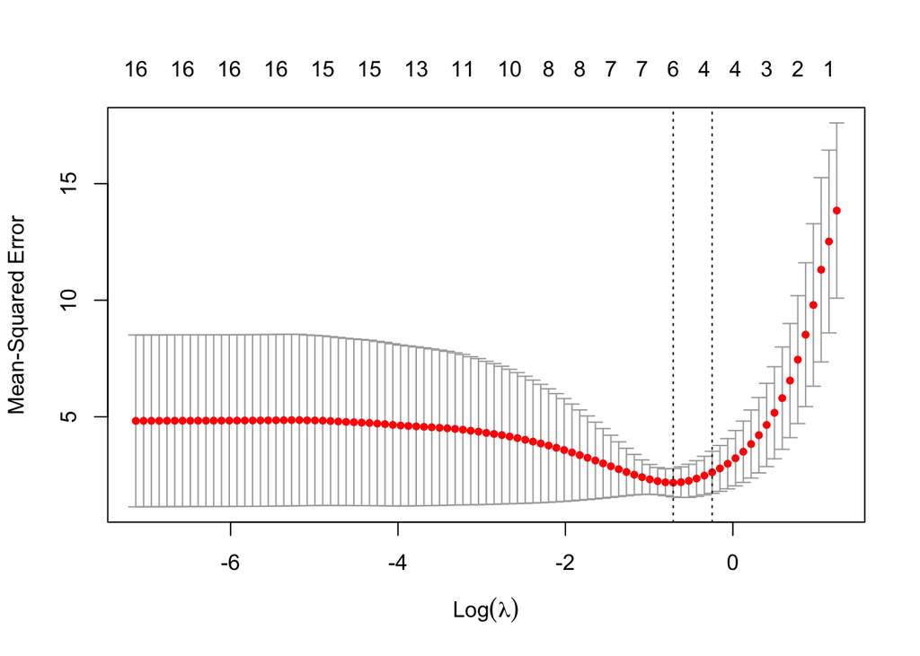

```r
x <- as.matrix(data3[1:(length(data3)-1)])
y <- data3$heart_attack
# fit a Lasso regression
set.seed(888)
cv_fit <- cv.glmnet(x, y, alpha = 1, nfolds = 8, standardize = TRUE)
plot(cv_fit)
```

```r
# use cross-validation to obtain lambda_min and lambda_1se
# coef(cv_fit)
print(cv_fit$lambda.min) # 0.4903668
```

```
## [1] 0.4903668
```

```r
print(cv_fit$lambda.1se) # 0.7808026
```

```
## [1] 0.7808026
```

```r
# explain
print("The lmabda.min is the extreme and best point in terms of the lowest cost function but the lambda.1se has extra bias for simplicity. I'd like to choose the lambda.1se, as it not only get good performance on current data but it's also more robust for new data and it's also easier to interpret and explain.")
```

```
## [1] "The lmabda.min is the extreme and best point in terms of the lowest cost function but the lambda.1se has extra bias for simplicity. I'd like to choose the lambda.1se, as it not only get good performance on current data but it's also more robust for new data and it's also easier to interpret …
```

## 2. Compare model outputs from questions one, three, and five.

```r
# calculate OOS R^2 for CV Lasso regression
testset <- as.matrix(data2[test,])
testset <- testset[,1:16]
# lambda = min
predict_min <- predict(cv_fit, s = cv_fit$lambda.min, newx = testset)
#y_bar <- mean(data2[-test,]$heart_attack)
d_lasso_min <- sum((data2[test,]$heart_attack - predict_min)^2) # (yi-y_hat)^2
d0_lasso_min <- sum((data2[test,]$heart_attack - y_bar)^2) # (yi-y_bar)^2
(R2_lasso_min <- 1 - (d_lasso_min/d0_lasso_min)) # 0.8720245
```

```
## [1] 0.8720245
```

```r
# lambda = 1se
predict_1se <- predict(cv_fit, s = cv_fit$lambda.1se, newx = testset)
d_lasso_1se <- sum((data2[test,]$heart_attack - predict_1se)^2) # (yi-y_hat)^2
d0_lasso_1se <- sum((data2[test,]$heart_attack - y_bar)^2) # (yi-y_bar)^2
(R2_lasso_1se <- 1 - (d_lasso_1se/d0_lasso_1se)) # 0.8527125
```

```
## [1] 0.8527125
```

```r
# model output
full # question one
```

```
##
## Call:  glm(formula = heart_attack ~ ., data = data2[-test, ])
##
## Coefficients:
## (Intercept)    past_pain      density          age       weight       height
##   16.178739    -0.269951   -20.948513    -0.006338     0.089833    -0.137895
## fat_free_wt     neck_dim    chest_dim    abdom_dim      hip_dim    thigh_dim
##   -0.129133     0.190100     0.125002     0.118288     0.073574     0.132341
##    knee_dim    ankle_dim   biceps_dim  forearm_dim  wrist_dim.1
##   -0.166587     0.120746     0.045052     0.064435     0.182155
##
## Degrees of Freedom: 183 Total (i.e. Null);  167 Residual
## Null Deviance:       2589
## Residual Deviance: 149.4     AIC: 519.8
```

```r
model# question three
```

```
## Linear Regression
##
## 184 samples
##  16 predictor
##
## No pre-processing
## Resampling: Cross-Validated (8 fold)
## Summary of sample sizes: 160, 161, 161, 161, 160, 161, ...
## Resampling results:
##
##   RMSE      Rsquared   MAE
##   1.535314  0.8827256  0.8211367
##
## Tuning parameter 'intercept' was held constant at a value of TRUE
```

```r
coef(cv_fit) # question five
```

```
## 17 x 1 sparse Matrix of class "dgCMatrix"
##                      s1
## (Intercept) -4.83470765
## past_pain    .
## density      .
## age          .
## weight       .
## height       .
## fat_free_wt  .
## neck_dim     .
## chest_dim    0.10185732
## abdom_dim    0.12231198
## hip_dim      0.05786521
## thigh_dim    0.04963001
## knee_dim     .
## ankle_dim    .
## biceps_dim   .
## forearm_dim  .
## wrist_dim.1  .
```

# Question 6: What is AIC, and how is it calculated? When to use AICc (corrected AIC)?

1. AIC is one of the Information Criteria in model selection to estimate the OOS deviance, formula = in-sample deviance + 2*df . It evaluates the relative quality of different models, by taking into account both the goodness of fit of the model (deviance) and the number of parameters used (degree of freedom). The smaller the AIC, the better the model.
2. AICc is the corrected AIC, especially when you only have small sample size or huge amount of parameters. It is preferred and regarded as the better information criteria to get more reliable estimate of the model quality.